# metabeta from R: reproducing the paper’s results

Prior-Amortized In-Context Bayesian Inference for GLMMs

This notebook reruns the metabeta results of the paper from R. Every model is fitted with `brm()` from the metabeta R package, the drop-in replacement for brms, with the default pipeline of the paper (the network’s posterior refined by four independence Metropolis-Hastings chains, 4,000 draws). The baselines (NUTS, ADVI, Laplace) are not rerun, so results that are defined as agreement with NUTS are not reproduced.

The paper’s results fall into three groups here:

- **Reproduced with the paper’s data, model and priors.** The prior sensitivity analysis on `sleepstudy`, `cbpp` and `Salamanders` (App. B.7, Fig. B15, Tables B10–B11) and the Bayes factors across priors (Sec. 3.4, Fig. B16). The data enter the network exactly as in the paper, so numbers agree up to Monte Carlo error.
- **Rerun with fresh simulations of the paper’s protocol.** The oracle benchmark (Sec. 3.1, Table 1, Tables B1–B3, B7, B8, Fig. 2), the raw flow against the IMH head (App. C.1), the stress tests on likelihood, prior and predictors (App. D.1–D.3) and the data-poor groups (App. D.5). The paper’s test sets are produced by its Python simulator, which bootstraps predictors and groups from 40 preprocessed real datasets. Here, datasets are drawn from the same hyper-prior, size classes and outcome calibration (App. F.2, F.3), with dataset sizes matched to the paper’s test sets but synthetic predictors. Expect the same picture, not identical numbers. One difference is systematic: on synthetic predictors, the IMH acceptance in the *large* and *huge* regimes is lower than on the paper’s test sets (as it is with the paper’s own simulator on synthetic designs), so calibration there falls somewhat behind the paper’s numbers, and many of those fits warn about it.
- **Not reproduced.** See the last section.

```r
rmarkdown::render("reproduce-paper.Rmd", params = list(n_datasets = 512, n_stress = 128))
```

# Setup

```r
library(metabeta)
# Load the Python side first: on Windows with conda, R's LAPACK must not load before torch.
install_metabeta()
library(ggplot2)
for (pkg in c("lme4", "glmmTMB", "MASS", "posterior")) {
  if (!requireNamespace(pkg, quietly = TRUE)) stop("Please install the package '", pkg, "'.")
}

dir.create("cache", showWarnings = FALSE)
# Evaluate `expr` once and keep its value in cache/<name>.rds.
cached <- function(name, expr) {
  path <- file.path("cache", paste0(name, ".rds"))
  if (file.exists(path)) return(readRDS(path))
  value <- expr
  saveRDS(value, path)
  value
}

# brm() with its wall-clock time; warnings are collected instead of printed.
fit_model <- function(...) {
  caught <- character()
  start <- proc.time()[["elapsed"]]
  fit <- withCallingHandlers(
    brm(...),
    warning = function(w) {
      caught <<- c(caught, conditionMessage(w))
      invokeRestart("muffleWarning")
    }
  )
  list(fit = fit, time = proc.time()[["elapsed"]] - start, warnings = caught)
}

pm <- function(x, digits = 2) sprintf("%.*f ± %.*f", digits, mean(x, na.rm = TRUE), digits, sd(x, na.rm = TRUE))
med_mad <- function(x, digits = 2) {
  x <- x[is.finite(x)]
  sprintf("%.*f ± %.*f", digits, median(x), digits, median(abs(x - median(x))))
}
```

# 1 Oracle benchmark (Sec. 3.1)

## 1.1 Simulator (App. F.2, F.3)

Each dataset draws its size class, then the number of fixed effects `d`, random effects `q`, groups `m` and group sizes; then its prior from the training hyper-prior; then the parameters and outcomes. As in the paper’s simulator, outcomes are calibrated (an R² ceiling for Gaussian outcomes, redraws and a cap on the spread of the linear predictor for Bernoulli and Poisson outcomes), and the stored prior is rescaled together with the parameters, so the parameters remain a draw from the prior the model is fitted with.

```r
REGIMES <- data.frame(regime = c("small", "medium", "large", "huge"), d_min = c(1, 5, 9, 13), d_max = c(4, 8, 12, 16), q_max = 2:5)
FAMILIES <- c("gaussian", "bernoulli", "poisson")
SD_FAMILIES <- c("halfnormal", "halfstudent", "exponential")

# Beta distribution rescaled to [low, high] with the given mode (kappa = 1: uniform)
rmodebeta <- function(n, low, high, mode, kappa) {
  t <- (mode - low) / (high - low)
  low + (high - low) * rbeta(n, 1 + (kappa - 1) * t, 1 + (kappa - 1) * (1 - t))
}
rlaplace <- function(n, scale) scale * (rexp(n) - rexp(n))
rloc <- function(family, n, loc, scale) loc + scale * if (family == "normal") rnorm(n) else rt(n, 5)
rpos <- function(family, n, scale) {
  scale * switch(family, halfnormal = abs(rnorm(n)), halfstudent = abs(rt(n, 5)), exponential = rexp(n))
}
# LKJ(eta) correlation matrix by the C-vine method (Lewandowski et al., 2009)
rlkj <- function(q, eta) {
  S <- diag(q)
  P <- matrix(0, q, q)
  beta <- eta + (q - 1) / 2
  for (k in seq_len(q - 1)) {
    beta <- beta - 1 / 2
    for (i in (k + 1):q) {
      P[k, i] <- 2 * rbeta(1, beta, beta) - 1
      p <- P[k, i]
      for (l in rev(seq_len(k - 1))) p <- p * sqrt((1 - P[l, i]^2) * (1 - P[l, k]^2)) + P[l, i] * P[l, k]
      S[k, i] <- S[i, k] <- p
    }
  }
  S
}

# Hyper-prior (App. F.3): spike-and-slab scale of the prior means, and (low, high, mode,
# concentration) of the prior scales of fixed effects, random-effect SDs and residual SD
HYPERPRIOR <- list(
  gaussian = list(nu = 0.5, b = c(0.01, 4, 0.5, 8), sd = c(0.01, 5, 1, 5), sigma = c(0.05, 8, 2, 5)),
  bernoulli = list(nu = 0.7, b = c(0.01, 3, 0.8, 6), sd = c(0.01, 2, 0.7, 5)),
  poisson = list(nu = 0.5, b = c(0.01, 1.5, 0.5, 6), sd = c(0.01, 1, 0.3, 5))
)

draw_prior <- function(family, d, q) {
  h <- HYPERPRIOR[[family]]
  scales <- function(n, v) rmodebeta(n, v[1], v[2], v[3], v[4])
  correlated <- q > 1 && runif(1) < if (q == 2) 0.8 else 0.5
  list(
    b_family = sample(c("normal", "student_t"), 1, prob = c(0.8, 0.2)),
    nu = ifelse(runif(d) < 0.9, 0, rlaplace(d, h$nu)),
    tau = scales(d, h$b),
    sd_family = sample(SD_FAMILIES, 1, prob = c(0.6, 0.3, 0.1)),
    tau_sd = scales(q, h$sd),
    sigma_family = sample(SD_FAMILIES, 1, prob = c(0.5, 0.4, 0.1)),
    tau_sigma = if (family == "gaussian") scales(1, h$sigma),
    eta = if (correlated) runif(1, 1, 2) else 0
  )
}

# d, q, m and group sizes of a size regime (App. F.2). d and q follow the size classes.
# The paper's oracle sets take m and the group sizes from real datasets, which yields
# smaller datasets than the synthetic training designs (median m 21-42, median n
# 406-512); m follows the training distribution without its many-groups component, and
# the total n is drawn around the reported median.
draw_sizes <- function(regime) {
  r <- REGIMES[REGIMES$regime == regime, ]
  d <- sample(r$d_min:r$d_max, 1)
  q_cap <- min(r$q_max, d)
  q <- min(floor(exp(runif(1, 0, log(q_cap + 1)))), q_cap)
  m_low <- max(5, max(d, q * (q + 1) / 2) + 4)
  m <- min(floor(rmodebeta(1, m_low, 201, m_low + min(0.08 * (200 - m_low), 20), 8)), 200)
  n_min <- max(5, q + 2)
  total <- min(max(exp(rnorm(1, log(450), 0.7)), m * n_min), 3000, 150 * m)
  ns <- if (runif(1) < 0.65) {
    rep(round(total / m), m)
  } else {
    w <- rgamma(m, exp(runif(1, log(8), log(40))))
    round(w / sum(w) * total)
  }
  ns <- pmin(pmax(ns, n_min), 150)
  while (sum(ns) > 3000) ns[which.max(ns)] <- ns[which.max(ns)] - 1
  list(d = d, q = q, m = m, ns = ns)
}

standardize <- function(x) (x - mean(x)) / sqrt(mean((x - mean(x))^2))
is_binary <- function(x) all(x %in% c(0, 1))

# k predictors: correlated Gaussians with a between-group share, turned into continuous,
# skewed, count and binary columns ("default"), or one of the out-of-distribution designs
# of App. D.3. Then preprocessed as in the paper: count-like columns log1p, non-binary
# columns z-scored, Poisson predictors clipped to [-5, 5].
draw_predictors <- function(k, groups, family, design = "default") {
  n <- length(groups)
  if (k == 0) return(matrix(numeric(), n, 0))
  m <- max(groups)
  A <- matrix(rnorm(k * k), k)
  L <- chol(cov2cor(crossprod(A) + diag(k)))
  between <- runif(k, 0, 0.5)
  latent <- (matrix(rnorm(n * k), n) %*% L) %*% diag(sqrt(1 - between), k) +
    (matrix(rnorm(m * k), m) %*% L)[groups, , drop = FALSE] %*% diag(sqrt(between), k)
  X <- switch(design,
    default = apply(latent, 2, function(x) {
      u <- runif(1)
      if (u < 0.25) as.numeric(x > quantile(x, runif(1, 0.2, 0.8)))
      else if (u < 0.35) log1p(rpois(n, exp(x)))
      else if (u < 0.5) exp(x / 2)
      else x
    }),
    t2 = qt(pnorm(latent), df = 2),
    cauchy = qcauchy(pnorm(latent)),
    clayton0.5 = , clayton0.9 = {
      # Clayton copula (Marshall-Olkin) with Kendall's tau 0.5 or 0.9, normal margins
      tau <- as.numeric(sub("clayton", "", design))
      theta <- 2 * tau / (1 - tau)
      v <- rgamma(n, 1 / theta)
      qnorm(pmin(pmax((1 + matrix(rexp(n * k), n) / v)^(-1 / theta), 1e-12), 1 - 1e-12))
    },
    longitudinal = cbind(ave(groups, groups, FUN = seq_along) - 1, latent[, -1])
  )
  X <- apply(matrix(X, n), 2, function(x) if (is_binary(x)) x else standardize(x))
  X <- matrix(X, n, dimnames = list(NULL, paste0("x", seq_len(k))))
  if (family == "poisson") X[] <- pmin(pmax(X, -5), 5)
  X
}

linear_predictor <- function(ds, p = ds$params) {
  X1 <- cbind(1, ds$X)
  drop(X1 %*% p$b) + rowSums(X1[, seq_len(ds$q), drop = FALSE] * p$r[ds$groups, , drop = FALSE])
}

draw_parameters <- function(ds) {
  pr <- ds$prior
  q <- ds$q
  m <- max(ds$groups)
  draw <- function() {
    sd <- pmax(rpos(pr$sd_family, q, pr$tau_sd), 1e-3)
    R <- if (pr$eta > 0) rlkj(q, pr$eta) else diag(q)
    list(
      b = rloc(pr$b_family, ds$d, pr$nu, pr$tau), sd = sd, R = R,
      r = matrix(rnorm(m * q), m) %*% chol(R) %*% diag(sd, q),
      sigma = if (ds$family == "gaussian") max(rpos(pr$sigma_family, 1, pr$tau_sigma), 1e-3)
    )
  }
  extreme <- function(eta) {
    switch(ds$family, gaussian = FALSE, bernoulli = mean(abs(eta) > 10) > 0.05, poisson = mean(eta > 10) > 0.01)
  }
  p <- draw()
  for (attempt in 2:20) {
    if (!extreme(linear_predictor(ds, p))) break
    p <- draw()
  }
  eta <- linear_predictor(ds, p)
  var_eta <- mean((eta - mean(eta))^2)
  if (ds$family == "gaussian") {
    r2_cap <- min(max(rnorm(1, 0.68 + 0.015 * (ds$d - 1) + 0.010 * (q - 1), 0.1), 0.45), 0.95)
    if (var_eta / (var_eta + p$sigma^2) > r2_cap) {
      sigma <- sqrt(var_eta * (1 - r2_cap) / r2_cap)
      pr$tau_sigma <- pr$tau_sigma * sigma / p$sigma
      p$sigma <- sigma
    }
  } else {
    cap <- if (ds$family == "bernoulli") runif(1, 2, 4) else runif(1, 1, 2)
    if (sqrt(var_eta) > cap) {
      k <- cap / sqrt(var_eta)
      p[c("b", "sd", "r")] <- lapply(p[c("b", "sd", "r")], `*`, k)
      pr[c("nu", "tau", "tau_sd")] <- lapply(pr[c("nu", "tau", "tau_sd")], `*`, k)
    }
  }
  ds$params <- p
  ds$prior <- pr
  ds$eta <- linear_predictor(ds, p)
  ds
}

# Outcomes from the model's likelihood, or from the contaminated ones of App. D.1
draw_outcomes <- function(ds, likelihood = "model", level = NULL) {
  eta <- ds$eta
  n <- length(eta)
  switch(likelihood,
    model = switch(ds$family,
      gaussian = eta + ds$params$sigma * rnorm(n),
      bernoulli = rbinom(n, 1, plogis(eta)),
      poisson = rpois(n, exp(eta))
    ),
    student_t = eta + ds$params$sigma * rt(n, level),
    logit_noise = rbinom(n, 1, plogis(eta + rnorm(n, 0, level))),
    negbin = rnbinom(n, size = level, mu = exp(eta))
  )
}

simulate_dataset <- function(family, regime) {
  s <- draw_sizes(regime)
  groups <- rep(seq_len(s$m), s$ns)
  ds <- list(
    family = family, regime = regime, d = s$d, q = s$q, groups = groups,
    X = draw_predictors(s$d - 1, groups, family), prior = draw_prior(family, s$d, s$q)
  )
  ds <- draw_parameters(ds)
  ds$y <- draw_outcomes(ds)
  ds
}
```

A dataset becomes a brms model. `0 + Intercept` puts the intercept prior on the intercept itself (brms’ default `Intercept` class refers to centered predictors), and the random effects are on the first `q` columns of the design, as in the paper.

```r
b_names <- function(ds) c("Intercept", colnames(ds$X))
re_names <- function(ds) b_names(ds)[seq_len(ds$q)]

model_data <- function(ds) data.frame(y = ds$y, ds$X, g = factor(sprintf("g%03d", ds$groups)))

model_formula <- function(ds) {
  bar <- if (ds$prior$eta > 0 || ds$q == 1) "|" else "||"
  re <- paste(c("1", re_names(ds)[-1]), collapse = " + ")
  as.formula(sprintf("y ~ %s + (%s %s g)", paste(c("0 + Intercept", colnames(ds$X)), collapse = " + "), re, bar))
}

positive_prior <- function(family, tau) {
  switch(family,
    halfnormal = sprintf("normal(0, %.6g)", tau),
    halfstudent = sprintf("student_t(5, 0, %.6g)", tau),
    exponential = sprintf("exponential(%.6g)", 1 / tau)
  )
}

model_prior <- function(ds, pr = ds$prior) {
  location <- if (pr$b_family == "normal") "normal(%.6g, %.6g)" else "student_t(5, %.6g, %.6g)"
  priors <- c(
    Map(function(k, nu, tau) set_prior(sprintf(location, nu, tau), class = "b", coef = k), b_names(ds), pr$nu, pr$tau),
    Map(function(k, tau) set_prior(positive_prior(pr$sd_family, tau), class = "sd", group = "g", coef = k), re_names(ds), pr$tau_sd),
    if (ds$family == "gaussian") list(set_prior(positive_prior(pr$sigma_family, pr$tau_sigma), class = "sigma")),
    if (pr$eta > 0) list(set_prior(sprintf("lkj(%.6g)", pr$eta), class = "cor"))
  )
  do.call(c, unname(priors))
}

# The generating parameters under their brms names
truth_table <- function(ds) {
  p <- ds$params
  re <- re_names(ds)
  levels <- sprintf("g%03d", seq_len(nrow(p$r)))
  pairs <- which(upper.tri(p$R), arr.ind = TRUE)
  rows <- list(
    data.frame(type = "b", slot = seq_along(p$b) - 1, variable = paste0("b_", b_names(ds)), value = p$b),
    data.frame(type = "sd", slot = seq_along(re) - 1, variable = paste0("sd_g__", re), value = p$sd),
    if (ds$family == "gaussian") data.frame(type = "sigma", slot = 0, variable = "sigma", value = p$sigma),
    if (ds$prior$eta > 0) {
      data.frame(
        type = "cor", slot = paste0(pairs[, 1] - 1, pairs[, 2] - 1),
        variable = sprintf("cor_g__%s__%s", re[pairs[, 1]], re[pairs[, 2]]), value = p$R[pairs]
      )
    },
    data.frame(
      type = "r", slot = rep(seq_along(re) - 1, each = length(levels)),
      variable = sprintf("r_g[%s,%s]", levels, rep(re, each = length(levels))), value = as.vector(p$r),
      n_i = rep(tabulate(ds$groups), length(re))
    )
  )
  rows <- lapply(Filter(Negate(is.null), rows), function(x) {
    x$slot <- as.character(x$slot)
    if (is.null(x$n_i)) x$n_i <- NA
    x
  })
  do.call(rbind, rows)
}
```

## 1.2 Fits and metrics (App. A.1)

For every parameter we keep the posterior mean, the fractional SBC rank (the share of draws below the true value) and whether the central intervals at the levels 1 − α, α ∈ {0.05, 0.10, …, 0.50}, cover the true value. Per dataset we keep the PSIS LOO-NLL (per observation), the wall-clock time of `brm()` and the IMH acceptance.

```r
ALPHA <- seq(0.05, 0.5, by = 0.05)
COVERAGE <- sprintf("c%02d", round(100 * (1 - ALPHA)))

score_draws <- function(fit, truth) {
  M <- unclass(as_draws_matrix(fit, variable = truth$variable))
  M <- M[, truth$variable, drop = FALSE]
  Q <- apply(M, 2, quantile, probs = c(ALPHA / 2, 1 - ALPHA / 2), names = FALSE)
  k <- length(ALPHA)
  value <- rep(truth$value, each = k)
  covered <- t(Q[seq_len(k), , drop = FALSE] <= value & value <= Q[k + seq_len(k), , drop = FALSE])
  colnames(covered) <- COVERAGE
  cbind(truth, mean = colMeans(M), rank = colMeans(sweep(M, 2, truth$value, "<")), covered)
}

fit_dataset <- function(ds, prior = model_prior(ds), algorithm = "sampling", seed = 1) {
  res <- tryCatch(
    fit_model(model_formula(ds), data = model_data(ds), family = ds$family, prior = prior, algorithm = algorithm, seed = seed),
    error = function(e) e
  )
  if (inherits(res, "error")) return(list(error = conditionMessage(res)))
  fit <- res$fit
  elpd <- suppressWarnings(loo(fit))$estimates["elpd_loo", "Estimate"]
  sg <- fit$metabeta$safeguards
  list(
    params = score_draws(fit, truth_table(ds)),
    info = data.frame(
      time = res$time, loo_nll = -elpd / length(ds$y), accept = if (is.null(sg$accept_rate)) NA else sg$accept_rate,
      warned = length(res$warnings) > 0, n = length(ds$y), m = max(ds$groups), d = ds$d, q = ds$q
    )
  )
}

# Fit a list of datasets (with the prior that `prior_of` returns for each); returns
# parameter rows and dataset rows, labelled with the dataset's position and `labels`
fit_all <- function(datasets, labels = list(), prior_of = model_prior, ...) {
  results <- lapply(seq_along(datasets), function(i) {
    ds <- datasets[[i]]
    r <- fit_dataset(ds, prior = prior_of(ds), ..., seed = i)
    id <- data.frame(id = i, family = ds$family, regime = ds$regime)
    id[names(labels)] <- labels
    if (!is.null(r$error)) return(list(info = cbind(id, error = r$error)))
    list(params = cbind(id[rep(1, nrow(r$params)), ], r$params, row.names = NULL), info = cbind(id, r$info, error = NA))
  })
  bind <- function(key) do.call(rbind, lapply(results, function(r) r[[key]]))
  infos <- lapply(results, `[[`, "info")
  columns <- unique(unlist(lapply(infos, names)))
  list(
    params = bind("params"),
    info = do.call(rbind, lapply(infos, function(x) {
      x[setdiff(columns, names(x))] <- NA
      x[columns]
    }))
  )
}

# EACE of a perfectly calibrated posterior scored on n parameters: the Monte Carlo
# floor of EACE (from the uniform SBC ranks of a calibrated posterior)
eace_floor <- function(n, sims = 200) {
  mean(replicate(sims, {
    u <- 2 * abs(runif(n) - 0.5)
    mean(abs(vapply(1 - ALPHA, function(level) mean(u <= level), 0) - (1 - ALPHA)))
  }))
}

# Metrics per parameter slot (e.g. b_1 or the random effects r_0 across groups)
slot_metrics <- function(rows) {
  out <- lapply(split(rows, list(rows$type, rows$slot), drop = TRUE), function(x) {
    err <- colMeans(as.matrix(x[COVERAGE])) - (1 - ALPHA)
    data.frame(
      type = x$type[1], slot = x$slot[1], n = nrow(x),
      r = if (nrow(x) > 2 && sd(x$value) > 0) cor(x$mean, x$value) else NA,
      nrmse = if (nrow(x) > 1) sqrt(mean((x$mean - x$value)^2)) / sd(x$value) else NA,
      ece = mean(err), eace = mean(abs(err)), floor = eace_floor(nrow(x)), c90 = mean(x$c90)
    )
  })
  do.call(rbind, out)
}
```

```r
oracle_data <- cached(sprintf("oracle-data-%d-%d", params$n_datasets, params$seed), {
  set.seed(params$seed)
  cells <- expand.grid(i = seq_len(params$n_datasets), regime = REGIMES$regime, family = FAMILIES, stringsAsFactors = FALSE)
  Map(simulate_dataset, cells$family, cells$regime)
})
oracle <- cached(sprintf("oracle-fits-%d-%d", params$n_datasets, params$seed), fit_all(oracle_data))
sprintf("%d datasets, %d failed", nrow(oracle$info), sum(!is.na(oracle$info$error)))
```

```
#> [1] "384 datasets, 0 failed"
```

## 1.3 Table 1, Tables B1 and B2

Metrics are averaged over parameter slots (mean ± SD; correlations are reported separately in Table B3 below); LOO-NLL and time are median ± MAD over datasets. Time is the wall clock of `brm()` on this machine’s CPU, including R’s own work; the paper’s 4-core CPU times of the Python pipeline are in Table B8 below.

With few datasets per regime, EACE is dominated by Monte Carlo error: `EACE floor` is the EACE that a perfectly calibrated posterior would show on the same number of parameters. The paper’s 512 datasets per regime put that floor near 0.01. The last two columns give the median IMH acceptance and the share of fits whose acceptance fell below the warning threshold of 0.1.

```r
regime_order <- function(x) factor(x, levels = REGIMES$regime)
oracle_table <- function(res) {
  p <- res$params[res$params$type != "cor", ]
  rows <- lapply(split(p, list(p$family, p$regime), drop = TRUE), function(x) {
    s <- slot_metrics(x)
    info <- res$info[res$info$family == x$family[1] & res$info$regime == x$regime[1] & is.na(res$info$error), ]
    data.frame(
      family = x$family[1], regime = x$regime[1], datasets = nrow(info),
      r = pm(s$r), NRMSE = pm(s$nrmse), ECE = pm(s$ece), EACE = pm(s$eace),
      `EACE floor` = sprintf("%.2f", mean(s$floor)),
      `LOO-NLL` = med_mad(info$loo_nll), `time [s]` = med_mad(info$time),
      acceptance = sprintf("%.2f", median(info$accept)), `acceptance < 0.1` = sprintf("%.0f%%", 100 * mean(info$accept < 0.1)),
      check.names = FALSE
    )
  })
  out <- do.call(rbind, rows)
  out[order(match(out$family, FAMILIES), regime_order(out$regime)), ]
}
oracle_table(oracle)
```

|  | family | regime | datasets | r | NRMSE | ECE | EACE | EACE floor | LOO-NLL | time [s] | acceptance | acceptance < 0.1 |
| --- | --- | --- | --- | --- | --- | --- | --- | --- | --- | --- | --- | --- |
| gaussian.small | gaussian | small | 32 | 0.96 ± 0.04 | 0.26 ± 0.12 | -0.01 ± 0.07 | 0.06 ± 0.04 | 0.06 | 2.08 ± 0.49 | 1.26 ± 0.22 | 0.66 | 0% |
| gaussian.medium | gaussian | medium | 32 | 0.93 ± 0.08 | 0.33 ± 0.19 | -0.04 ± 0.10 | 0.07 ± 0.08 | 0.07 | 2.41 ± 0.47 | 1.35 ± 0.18 | 0.32 | 0% |
| gaussian.large | gaussian | large | 32 | 0.94 ± 0.08 | 0.30 ± 0.18 | -0.04 ± 0.13 | 0.08 ± 0.12 | 0.06 | 2.24 ± 0.37 | 1.50 ± 0.23 | 0.11 | 41% |
| gaussian.huge | gaussian | huge | 32 | 0.95 ± 0.05 | 0.27 ± 0.14 | 0.02 ± 0.09 | 0.08 ± 0.06 | 0.08 | 2.22 ± 0.47 | 1.61 ± 0.26 | 0.05 | 72% |
| bernoulli.small | bernoulli | small | 32 | 0.91 ± 0.12 | 0.36 ± 0.25 | -0.01 ± 0.04 | 0.05 ± 0.02 | 0.06 | 0.53 ± 0.08 | 2.30 ± 0.43 | 0.55 | 0% |
| bernoulli.medium | bernoulli | medium | 32 | 0.91 ± 0.09 | 0.37 ± 0.17 | 0.01 ± 0.08 | 0.07 ± 0.04 | 0.06 | 0.42 ± 0.05 | 2.58 ± 0.56 | 0.39 | 0% |
| bernoulli.large | bernoulli | large | 32 | 0.89 ± 0.13 | 0.40 ± 0.23 | 0.01 ± 0.09 | 0.08 ± 0.06 | 0.06 | 0.42 ± 0.06 | 3.39 ± 0.44 | 0.18 | 3% |
| bernoulli.huge | bernoulli | huge | 32 | 0.83 ± 0.19 | 0.55 ± 0.46 | -0.01 ± 0.08 | 0.07 ± 0.05 | 0.06 | 0.36 ± 0.05 | 3.01 ± 0.41 | 0.08 | 69% |
| poisson.small | poisson | small | 32 | 0.95 ± 0.08 | 0.26 ± 0.21 | 0.02 ± 0.08 | 0.07 ± 0.04 | 0.07 | 1.36 ± 0.20 | 2.17 ± 0.28 | 0.64 | 3% |
| poisson.medium | poisson | medium | 32 | 0.94 ± 0.07 | 0.30 ± 0.17 | -0.04 ± 0.06 | 0.07 ± 0.03 | 0.06 | 1.37 ± 0.18 | 2.82 ± 0.38 | 0.22 | 12% |
| poisson.large | poisson | large | 32 | 0.94 ± 0.08 | 0.28 ± 0.19 | -0.06 ± 0.10 | 0.09 ± 0.07 | 0.06 | 1.50 ± 0.19 | 3.32 ± 0.50 | 0.05 | 75% |
| poisson.huge | poisson | huge | 32 | 0.90 ± 0.16 | 0.34 ± 0.25 | -0.03 ± 0.07 | 0.07 ± 0.05 | 0.06 | 1.42 ± 0.20 | 3.53 ± 0.73 | 0.03 | 97% |

The paper’s values for metabeta (Table 1, Tables B1 and B2):

```r
paper_oracle <- data.frame(
  family = rep(FAMILIES, each = 4), regime = REGIMES$regime,
  r = c("0.94 ± 0.04", "0.95 ± 0.03", "0.96 ± 0.03", "0.96 ± 0.03", "0.89 ± 0.09", "0.90 ± 0.09", "0.88 ± 0.11", "0.86 ± 0.12", "0.92 ± 0.08", "0.94 ± 0.06", "0.94 ± 0.07", "0.93 ± 0.09"),
  NRMSE = c("0.32 ± 0.13", "0.29 ± 0.10", "0.28 ± 0.09", "0.29 ± 0.08", "0.42 ± 0.17", "0.41 ± 0.16", "0.43 ± 0.18", "0.46 ± 0.18", "0.35 ± 0.16", "0.32 ± 0.15", "0.30 ± 0.15", "0.33 ± 0.17"),
  ECE = c("0.00 ± 0.02", "0.00 ± 0.04", "0.00 ± 0.02", "-0.02 ± 0.03", "0.00 ± 0.02", "0.00 ± 0.02", "0.00 ± 0.02", "-0.01 ± 0.03", "0.00 ± 0.04", "0.00 ± 0.02", "-0.02 ± 0.02", "-0.03 ± 0.03"),
  EACE = c("0.02 ± 0.01", "0.02 ± 0.03", "0.02 ± 0.02", "0.03 ± 0.02", "0.02 ± 0.01", "0.02 ± 0.01", "0.02 ± 0.01", "0.03 ± 0.02", "0.03 ± 0.03", "0.02 ± 0.01", "0.03 ± 0.02", "0.04 ± 0.03"),
  `LOO-NLL` = c("2.21 ± 0.53", "2.26 ± 0.50", "2.27 ± 0.43", "2.25 ± 0.46", "0.55 ± 0.09", "0.45 ± 0.06", "0.43 ± 0.05", "0.41 ± 0.05", "1.34 ± 0.22", "1.36 ± 0.17", "1.39 ± 0.16", "1.41 ± 0.14"),
  check.names = FALSE
)
paper_oracle
```

| family | regime | r | NRMSE | ECE | EACE | LOO-NLL |
| --- | --- | --- | --- | --- | --- | --- |
| gaussian | small | 0.94 ± 0.04 | 0.32 ± 0.13 | 0.00 ± 0.02 | 0.02 ± 0.01 | 2.21 ± 0.53 |
| gaussian | medium | 0.95 ± 0.03 | 0.29 ± 0.10 | 0.00 ± 0.04 | 0.02 ± 0.03 | 2.26 ± 0.50 |
| gaussian | large | 0.96 ± 0.03 | 0.28 ± 0.09 | 0.00 ± 0.02 | 0.02 ± 0.02 | 2.27 ± 0.43 |
| gaussian | huge | 0.96 ± 0.03 | 0.29 ± 0.08 | -0.02 ± 0.03 | 0.03 ± 0.02 | 2.25 ± 0.46 |
| bernoulli | small | 0.89 ± 0.09 | 0.42 ± 0.17 | 0.00 ± 0.02 | 0.02 ± 0.01 | 0.55 ± 0.09 |
| bernoulli | medium | 0.90 ± 0.09 | 0.41 ± 0.16 | 0.00 ± 0.02 | 0.02 ± 0.01 | 0.45 ± 0.06 |
| bernoulli | large | 0.88 ± 0.11 | 0.43 ± 0.18 | 0.00 ± 0.02 | 0.02 ± 0.01 | 0.43 ± 0.05 |
| bernoulli | huge | 0.86 ± 0.12 | 0.46 ± 0.18 | -0.01 ± 0.03 | 0.03 ± 0.02 | 0.41 ± 0.05 |
| poisson | small | 0.92 ± 0.08 | 0.35 ± 0.16 | 0.00 ± 0.04 | 0.03 ± 0.03 | 1.34 ± 0.22 |
| poisson | medium | 0.94 ± 0.06 | 0.32 ± 0.15 | 0.00 ± 0.02 | 0.02 ± 0.01 | 1.36 ± 0.17 |
| poisson | large | 0.94 ± 0.07 | 0.30 ± 0.15 | -0.02 ± 0.02 | 0.03 ± 0.02 | 1.39 ± 0.16 |
| poisson | huge | 0.93 ± 0.09 | 0.33 ± 0.17 | -0.03 ± 0.03 | 0.04 ± 0.03 | 1.41 ± 0.14 |

## 1.4 Figure 2

Recovery and calibration on the *medium* Gaussian datasets: posterior means against the generating values, empirical coverage of the central intervals against their nominal level (one line per parameter slot), and the difference between the empirical CDF of the SBC ranks and the uniform CDF with a simultaneous 95% band (Säilynoja et al., 2022).

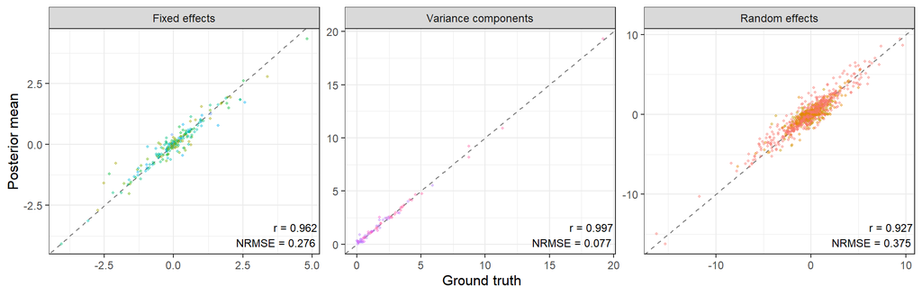

```r
param_label <- function(type, slot) {
  ifelse(type == "b", paste0("beta[", slot, "]"), ifelse(type == "sd", paste0("sigma[", slot, "]"),
    ifelse(type == "sigma", "sigma[epsilon]", paste0("alpha[", slot, "]"))))
}
panel_of <- c(b = "Fixed effects", sd = "Variance components", sigma = "Variance components", r = "Random effects")

figure2 <- function(res, family, regime) {
  rows <- res$params[res$params$family == family & res$params$regime == regime & res$params$type != "cor", ]
  rows$panel <- factor(panel_of[rows$type], levels = unique(panel_of))
  rows$parameter <- param_label(rows$type, rows$slot)
  stats <- do.call(rbind, lapply(split(rows, rows$panel), function(x) {
    data.frame(panel = x$panel[1], label = sprintf("r = %.3f\nNRMSE = %.3f", cor(x$mean, x$value),
      sqrt(mean((x$mean - x$value)^2)) / sd(x$value)))
  }))
  recovery <- ggplot(rows, aes(value, mean, colour = parameter)) +
    geom_abline(linetype = 2, colour = "grey50") +
    geom_point(size = 0.6, alpha = 0.4) +
    geom_text(data = stats, aes(x = Inf, y = -Inf, label = label), inherit.aes = FALSE, hjust = 1.05, vjust = -0.3, size = 3) +
    facet_wrap(~panel, scales = "free") +
    labs(x = "Ground truth", y = "Posterior mean", colour = NULL) +
    theme_bw() + theme(legend.position = "none")

  coverage <- do.call(rbind, lapply(split(rows, rows$parameter), function(x) {
    data.frame(parameter = x$parameter[1], nominal = 1 - ALPHA, empirical = colMeans(as.matrix(x[COVERAGE])))
  }))
  s <- slot_metrics(rows)
  coverage_plot <- ggplot(coverage, aes(nominal, empirical, colour = parameter)) +
    geom_abline(linetype = 2, colour = "grey50") +
    geom_line() +
    annotate("text", x = 0.95, y = 0.5, hjust = 1, size = 3,
      label = sprintf("ECE = %.2f%%\nEACE = %.2f%%", 100 * mean(s$ece), 100 * mean(s$eace))) +
    scale_colour_discrete(labels = function(x) parse(text = x)) +
    labs(x = "Nominal coverage", y = "Empirical coverage", colour = NULL) +
    theme_bw()
  list(recovery = recovery, coverage = coverage_plot, sbc = sbc_plot(rows))
}

# Simultaneous ECDF band for n uniform ranks (Säilynoja et al., 2022), by simulation
ecdf_band <- function(n, z, prob = 0.95, n_sim = 1000) {
  smallest <- replicate(n_sim, {
    counts <- findInterval(z, sort(runif(n)))
    min(2 * pmin(pbinom(counts, n, z), 1 - pbinom(counts - 1, n, z)))
  })
  gamma <- quantile(smallest, 1 - prob)
  data.frame(z = z, lower = qbinom(gamma / 2, n, z) / n - z, upper = qbinom(1 - gamma / 2, n, z) / n - z)
}

sbc_plot <- function(rows) {
  z <- seq(0.005, 0.995, by = 0.005)
  curves <- do.call(rbind, lapply(split(rows, rows$parameter), function(x) {
    data.frame(parameter = x$parameter[1], z = z, diff = ecdf(x$rank)(z) - z)
  }))
  bands <- rbind(
    cbind(ecdf_band(min(table(rows$parameter[rows$type != "r"])), z), kind = "global"),
    cbind(ecdf_band(min(table(rows$parameter[rows$type == "r"])), z), kind = "local")
  )
  ggplot(curves, aes(z, diff)) +
    geom_ribbon(data = bands, aes(z, ymin = lower, ymax = upper, fill = kind), inherit.aes = FALSE, alpha = 0.25) +
    geom_hline(yintercept = 0, colour = "grey50") +
    geom_line(aes(colour = parameter)) +
    scale_colour_discrete(labels = function(x) parse(text = x)) +
    scale_fill_manual(values = c(global = "grey50", local = "lightblue"), name = "95% band") +
    labs(x = "SBC fractional rank", y = expression(Delta ~ "uniform ECDF"), colour = NULL) +
    theme_bw()
}

fig2 <- figure2(oracle, "gaussian", "medium")
fig2$recovery
```

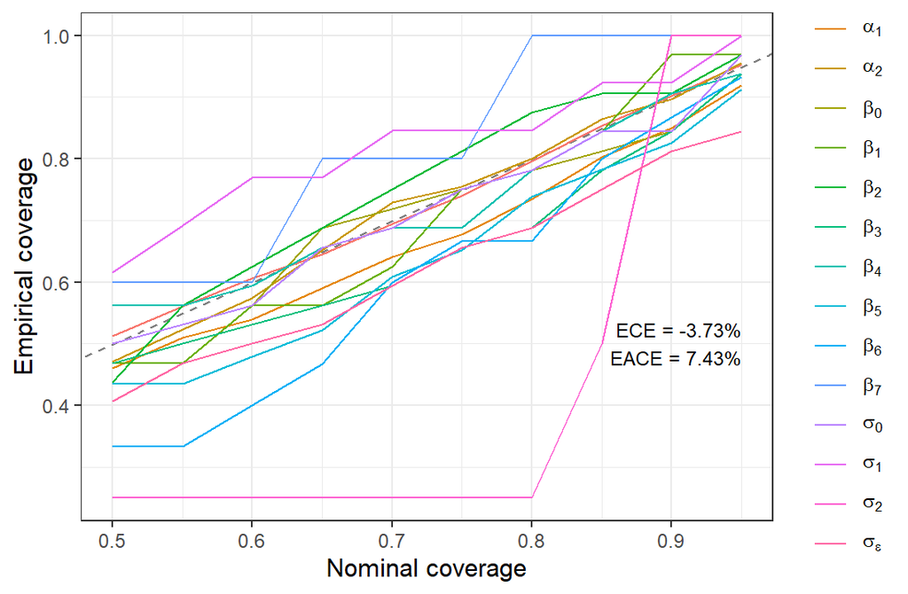

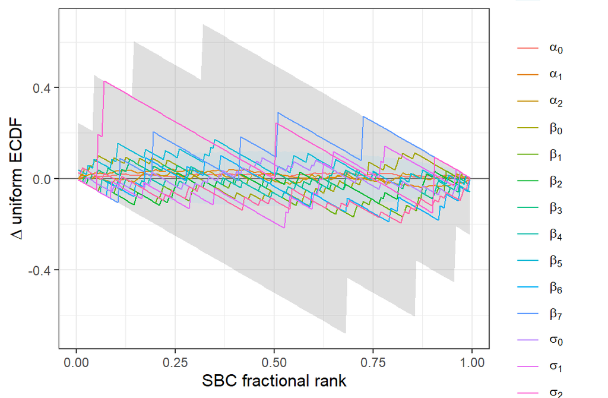

```r
fig2$coverage
fig2$sbc
```

## 1.5 Random-effect correlations (Table B3) and parameter classes (Table B7)

```r
cors <- oracle$params[oracle$params$type == "cor", ]
table_b3 <- do.call(rbind, lapply(split(cors, list(cors$family, cors$regime), drop = TRUE), function(x) {
  s <- slot_metrics(x)
  data.frame(family = x$family[1], regime = x$regime[1], datasets = length(unique(x$id)),
    r = pm(s$r), NRMSE = pm(s$nrmse), ECE = pm(s$ece), EACE = pm(s$eace))
}))
table_b3[order(match(table_b3$family, FAMILIES), regime_order(table_b3$regime)), ]
```

|  | family | regime | datasets | r | NRMSE | ECE | EACE |
| --- | --- | --- | --- | --- | --- | --- | --- |
| gaussian.small | gaussian | small | 9 | 0.92 ± NA | 0.48 ± NA | 0.12 ± NA | 0.12 ± NA |
| gaussian.medium | gaussian | medium | 8 | 0.64 ± NA | 0.82 ± NA | -0.13 ± 0.19 | 0.27 ± 0.19 |
| gaussian.large | gaussian | large | 12 | 0.73 ± 0.13 | 1.27 ± 0.84 | -0.04 ± 0.17 | 0.16 ± 0.06 |
| gaussian.huge | gaussian | huge | 8 | 0.79 ± 0.17 | 0.59 ± 0.29 | 0.09 ± 0.26 | 0.26 ± 0.09 |
| bernoulli.small | bernoulli | small | 8 | 0.35 ± NA | 0.88 ± NA | -0.02 ± NA | 0.08 ± NA |
| bernoulli.medium | bernoulli | medium | 16 | 0.56 ± 0.02 | 0.80 ± 0.01 | 0.06 ± 0.09 | 0.10 ± 0.03 |
| bernoulli.large | bernoulli | large | 10 | 0.24 ± 0.90 | 4.16 ± 7.91 | 0.14 ± 0.11 | 0.17 ± 0.07 |
| bernoulli.huge | bernoulli | huge | 15 | -0.20 ± 0.62 | 1.61 ± 1.40 | -0.05 ± 0.15 | 0.16 ± 0.06 |
| poisson.small | poisson | small | 3 | 0.78 ± NA | 0.66 ± NA | -0.12 ± NA | 0.18 ± NA |
| poisson.medium | poisson | medium | 12 | 0.87 ± 0.12 | 0.81 ± 0.11 | 0.05 ± 0.25 | 0.22 ± 0.08 |
| poisson.large | poisson | large | 12 | 0.48 ± 0.60 | 0.99 ± 0.31 | -0.08 ± 0.09 | 0.13 ± 0.03 |
| poisson.huge | poisson | huge | 17 | 0.42 ± 0.22 | 0.88 ± 0.13 | -0.14 ± 0.28 | 0.26 ± 0.19 |

The paper reports, for metabeta, r = 0.63–0.69 and NRMSE = 0.73–0.78 for the Gaussian correlations and lower values for Bernoulli outcomes (Table B3): correlations are the least identified parameters.

```r
class_of <- c(b = "beta", sd = "sigma", sigma = "sigma", r = "alpha")
p <- oracle$params[oracle$params$type != "cor", ]
p$class <- class_of[p$type]
table_b7 <- do.call(rbind, lapply(FAMILIES, function(f) {
  by_class <- sapply(c("beta", "sigma", "alpha"), function(k) {
    s <- slot_metrics(p[p$family == f & p$class == k, ])
    sprintf("%.2f (%.2f)", mean(s$nrmse, na.rm = TRUE), mean(s$r, na.rm = TRUE))
  })
  info <- oracle$info[oracle$info$family == f & is.na(oracle$info$error), ]
  data.frame(family = f, `beta: NRMSE (r)` = by_class[["beta"]], `sigma: NRMSE (r)` = by_class[["sigma"]],
    `alpha: NRMSE (r)` = by_class[["alpha"]], `LOO-NLL` = sprintf("%.2f", median(info$loo_nll)),
    `time [s]` = sprintf("%.2f", median(info$time)), check.names = FALSE)
}))
table_b7
```

| family | beta: NRMSE (r) | sigma: NRMSE (r) | alpha: NRMSE (r) | LOO-NLL | time [s] |
| --- | --- | --- | --- | --- | --- |
| gaussian | 0.21 (0.98) | 0.24 (0.96) | 0.41 (0.91) | 2.24 | 1.37 |
| bernoulli | 0.27 (0.96) | 0.90 (0.81) | 0.80 (0.60) | 0.44 | 2.86 |
| poisson | 0.17 (0.98) | 0.36 (0.93) | 0.68 (0.71) | 1.41 | 2.87 |

Paper (Table B7, metabeta): Gaussian 0.28 (0.96), 0.22 (0.97), 0.44 (0.90), LOO-NLL 2.25; Bernoulli 0.31 (0.95), 0.49 (0.88), 0.70 (0.71), 0.46; Poisson 0.21 (0.98), 0.36 (0.93), 0.58 (0.81), 1.38.

## 1.6 Runtime (Table B8, Fig. B14)

Median wall-clock time per dataset of `brm()` on this machine (one fit at a time, 4,000 draws), next to the paper’s times of the Python pipeline on four Xeon CPU cores.

```r
info <- oracle$info[is.na(oracle$info$error), ]
runtime <- aggregate(time ~ family + regime, info, median)
runtime <- reshape(runtime, idvar = "family", timevar = "regime", direction = "wide")
names(runtime) <- sub("time.", "", names(runtime))
runtime <- runtime[match(FAMILIES, runtime$family), c("family", REGIMES$regime)]
cbind(runtime, paper = c("0.54 / 0.61 / 0.70 / 0.86", "0.78 / 1.03 / 1.34 / 2.21", "1.15 / 1.55 / 2.01 / 2.26"))
```

|  | family | small | medium | large | huge | paper |
| --- | --- | --- | --- | --- | --- | --- |
| 2 | gaussian | 1.255 | 1.355 | 1.495 | 1.610 | 0.54 / 0.61 / 0.70 / 0.86 |
| 1 | bernoulli | 2.305 | 2.580 | 3.390 | 3.015 | 0.78 / 1.03 / 1.34 / 2.21 |
| 3 | poisson | 2.165 | 2.825 | 3.315 | 3.535 | 1.15 / 1.55 / 2.01 / 2.26 |

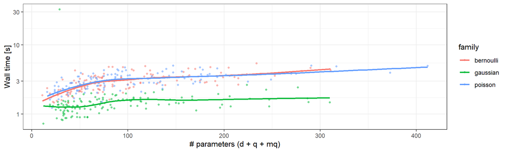

```r
info$n_params <- info$d + info$q + info$m * info$q
ggplot(info, aes(n_params, time, colour = family)) +
  geom_point(alpha = 0.5, size = 1) +
  geom_smooth(se = FALSE, method = "loess", formula = y ~ x) +
  scale_y_log10() +
  labs(x = "# parameters (d + q + mq)", y = "Wall time [s]") +
  theme_bw()
```

## 1.7 The IMH head against the raw flow (App. C.1)

`algorithm = "meanfield"` returns the network’s posterior (MB⁰) without the Metropolis-Hastings correction. On the first `n_ablation` datasets of every family and regime: the predictive gap of the raw flow to metabeta, and the calibration of both. The paper reports gaps of the raw flow to NUTS of 0.06–1.13 nats, growing with model size, which the IMH head closes to ≤ 0.01 (Tables C2–C4). On a CPU, the raw flow is the slower of the two for Bernoulli and Poisson outcomes, because it samples the random effects with the local network (Table B8).

```r
ablation_ids <- which(ave(seq_along(oracle_data), vapply(oracle_data, function(ds) paste(ds$family, ds$regime), ""), FUN = seq_along) <= params$n_ablation)
raw_flow <- cached(sprintf("oracle-flow-%d-%d-%d", params$n_datasets, params$n_ablation, params$seed), {
  res <- fit_all(oracle_data[ablation_ids], algorithm = "meanfield")
  res$info$id <- ablation_ids[res$info$id]
  if (!is.null(res$params)) res$params$id <- ablation_ids[res$params$id]
  res
})

ablation <- do.call(rbind, lapply(split(raw_flow$info, list(raw_flow$info$family, raw_flow$info$regime), drop = TRUE), function(x) {
  mb <- oracle$info[match(x$id, oracle$info$id), ]
  flow_rows <- raw_flow$params[raw_flow$params$family == x$family[1] & raw_flow$params$regime == x$regime[1] & raw_flow$params$type != "cor", ]
  mb_rows <- oracle$params[oracle$params$id %in% x$id & oracle$params$type != "cor", ]
  s0 <- slot_metrics(flow_rows)
  s1 <- slot_metrics(mb_rows)
  data.frame(
    family = x$family[1], regime = x$regime[1], datasets = nrow(x),
    `LOO-NLL MB0 - MB` = med_mad(x$loo_nll - mb$loo_nll, 3),
    `ECE MB0` = pm(s0$ece), `ECE MB` = pm(s1$ece), `EACE MB0` = pm(s0$eace), `EACE MB` = pm(s1$eace),
    `time MB0 [s]` = sprintf("%.2f", median(x$time)), check.names = FALSE
  )
}))
ablation[order(match(ablation$family, FAMILIES), regime_order(ablation$regime)), ]
```

|  | family | regime | datasets | LOO-NLL MB0 - MB | ECE MB0 | ECE MB | EACE MB0 | EACE MB | time MB0 [s] |
| --- | --- | --- | --- | --- | --- | --- | --- | --- | --- |
| gaussian.small | gaussian | small | 8 | 0.002 ± 0.002 | -0.02 ± 0.12 | -0.03 ± 0.12 | 0.11 ± 0.07 | 0.11 ± 0.08 | 0.87 |
| gaussian.medium | gaussian | medium | 8 | 0.010 ± 0.003 | -0.04 ± 0.18 | -0.04 ± 0.18 | 0.14 ± 0.13 | 0.14 ± 0.14 | 0.87 |
| gaussian.large | gaussian | large | 8 | 0.025 ± 0.006 | 0.00 ± 0.15 | -0.03 ± 0.18 | 0.14 ± 0.10 | 0.15 ± 0.12 | 1.09 |
| gaussian.huge | gaussian | huge | 8 | 0.085 ± 0.041 | 0.05 ± 0.18 | 0.02 ± 0.17 | 0.16 ± 0.10 | 0.15 ± 0.09 | 1.28 |
| bernoulli.small | bernoulli | small | 8 | 0.001 ± 0.001 | -0.10 ± 0.16 | -0.13 ± 0.19 | 0.18 ± 0.06 | 0.20 ± 0.10 | 8.18 |
| bernoulli.medium | bernoulli | medium | 8 | 0.017 ± 0.004 | 0.05 ± 0.21 | 0.09 ± 0.14 | 0.15 ± 0.15 | 0.13 ± 0.10 | 14.27 |
| bernoulli.large | bernoulli | large | 8 | 0.044 ± 0.008 | -0.00 ± 0.12 | -0.00 ± 0.15 | 0.12 ± 0.07 | 0.14 ± 0.08 | 14.38 |
| bernoulli.huge | bernoulli | huge | 8 | 0.081 ± 0.031 | 0.02 ± 0.16 | -0.01 ± 0.18 | 0.15 ± 0.07 | 0.16 ± 0.09 | 10.14 |
| poisson.small | poisson | small | 8 | 0.005 ± 0.004 | -0.02 ± 0.11 | -0.03 ± 0.13 | 0.11 ± 0.04 | 0.13 ± 0.06 | 7.10 |
| poisson.medium | poisson | medium | 8 | 0.040 ± 0.030 | -0.00 ± 0.08 | 0.00 ± 0.10 | 0.10 ± 0.04 | 0.09 ± 0.05 | 11.58 |
| poisson.large | poisson | large | 8 | 0.938 ± 0.868 | -0.05 ± 0.18 | -0.07 ± 0.18 | 0.15 ± 0.12 | 0.15 ± 0.13 | 9.96 |
| poisson.huge | poisson | huge | 8 | 1.347 ± 1.074 | 0.00 ± 0.15 | -0.01 ± 0.15 | 0.14 ± 0.09 | 0.14 ± 0.09 | 11.65 |

## 1.8 Data-poor groups (App. D.5, Tables D13–D15)

Local parameters by the per-group information ratio ρ = nᵢ / (d + q), and global parameters by γ = n / p_all with p_all = d + mq + q(q + 1)/2 + 1, pooled over regimes. `c90` is the coverage of the 90% interval.

```r
pooled <- function(x) {
  err <- colMeans(as.matrix(x[COVERAGE])) - (1 - ALPHA)
  c(EACE = mean(abs(err)), NRMSE = sqrt(mean((x$mean - x$value)^2)) / sd(x$value), c90 = mean(x$c90))
}
local_rows <- merge(oracle$params[oracle$params$type == "r", ], oracle$info[c("id", "d", "q")], by = "id")
local_rows$rho <- cut(local_rows$n_i / (local_rows$d + local_rows$q), c(0, 0.5, 1, 2, 5, Inf), right = FALSE)
do.call(rbind, lapply(split(local_rows, list(local_rows$family, local_rows$rho), drop = TRUE), function(x) {
  data.frame(family = x$family[1], rho = x$rho[1], groups = nrow(x), t(round(pooled(x), 3)))
}))
```

|  | family | rho | groups | EACE | NRMSE | c90 |
| --- | --- | --- | --- | --- | --- | --- |
| bernoulli.[0,0.5) | bernoulli | [0,0.5) | 2577 | 0.045 | 0.896 | 0.911 |
| gaussian.[0,0.5) | gaussian | [0,0.5) | 2576 | 0.022 | 0.529 | 0.876 |
| poisson.[0,0.5) | poisson | [0,0.5) | 3153 | 0.022 | 0.696 | 0.885 |
| bernoulli.[0.5,1) | bernoulli | [0.5,1) | 3986 | 0.005 | 0.798 | 0.900 |
| gaussian.[0.5,1) | gaussian | [0.5,1) | 3127 | 0.003 | 0.490 | 0.901 |
| poisson.[0.5,1) | poisson | [0.5,1) | 3467 | 0.008 | 0.658 | 0.888 |
| bernoulli.[1,2) | bernoulli | [1,2) | 2310 | 0.015 | 0.597 | 0.907 |
| gaussian.[1,2) | gaussian | [1,2) | 1786 | 0.003 | 0.305 | 0.905 |
| poisson.[1,2) | poisson | [1,2) | 2694 | 0.009 | 0.444 | 0.897 |
| bernoulli.[2,5) | bernoulli | [2,5) | 1620 | 0.033 | 0.567 | 0.888 |
| gaussian.[2,5) | gaussian | [2,5) | 1830 | 0.006 | 0.318 | 0.893 |
| poisson.[2,5) | poisson | [2,5) | 1708 | 0.011 | 0.523 | 0.899 |
| bernoulli.[5,Inf) | bernoulli | [5,Inf) | 487 | 0.074 | 0.536 | 0.842 |
| gaussian.[5,Inf) | gaussian | [5,Inf) | 633 | 0.012 | 0.255 | 0.907 |
| poisson.[5,Inf) | poisson | [5,Inf) | 288 | 0.033 | 0.473 | 0.885 |

```r
global_rows <- merge(oracle$params[oracle$params$type %in% c("b", "sd", "sigma"), ], oracle$info[c("id", "d", "q", "m", "n", "loo_nll")], by = "id")
global_rows$gamma <- with(global_rows, cut(n / (d + m * q + q * (q + 1) / 2 + 1), c(0, 2, 4, 8, Inf), right = FALSE))
do.call(rbind, lapply(split(global_rows, list(global_rows$family, global_rows$gamma), drop = TRUE), function(x) {
  data.frame(family = x$family[1], gamma = x$gamma[1], datasets = length(unique(x$id)), t(round(pooled(x), 3)),
    LOO = round(mean(x$loo_nll[!duplicated(x$id)]), 3))
}))
```

|  | family | gamma | datasets | EACE | NRMSE | c90 | LOO |
| --- | --- | --- | --- | --- | --- | --- | --- |
| bernoulli.[0,2) | bernoulli | [0,2) | 7 | 0.033 | 0.303 | 0.895 | 0.415 |
| gaussian.[0,2) | gaussian | [0,2) | 10 | 0.025 | 0.230 | 0.865 | 2.471 |
| poisson.[0,2) | poisson | [0,2) | 14 | 0.029 | 0.232 | 0.855 | 1.509 |
| bernoulli.[2,4) | bernoulli | [2,4) | 35 | 0.016 | 0.294 | 0.870 | 0.419 |
| gaussian.[2,4) | gaussian | [2,4) | 17 | 0.012 | 0.186 | 0.879 | 2.743 |
| poisson.[2,4) | poisson | [2,4) | 26 | 0.052 | 0.226 | 0.847 | 1.374 |
| bernoulli.[4,8) | bernoulli | [4,8) | 48 | 0.006 | 0.268 | 0.907 | 0.460 |
| gaussian.[4,8) | gaussian | [4,8) | 32 | 0.020 | 0.146 | 0.856 | 2.212 |
| poisson.[4,8) | poisson | [4,8) | 49 | 0.044 | 0.148 | 0.875 | 1.397 |
| bernoulli.[8,Inf) | bernoulli | [8,Inf) | 38 | 0.014 | 0.207 | 0.886 | 0.417 |
| gaussian.[8,Inf) | gaussian | [8,Inf) | 69 | 0.019 | 0.130 | 0.886 | 2.156 |
| poisson.[8,Inf) | poisson | [8,Inf) | 39 | 0.047 | 0.119 | 0.845 | 1.494 |

# 2 Stress tests (App. D.1–D.3)

Each condition takes the first `n_stress` oracle datasets of a family (spread evenly over the size regimes) and perturbs one thing: the likelihood the outcomes come from (D.1), the prior the model is fitted with (D.2), or the distribution of the predictors (D.3). The fitted model is always the GLMM of Section 1. The tables score the posteriors against the generating parameters: recovery (NRMSE) and calibration (EACE) of the global (g) and local (l) parameters, as in the right half of Tables D1–D9, plus the median IMH acceptance and the share of fits with a warning. In the paper, metabeta and NUTS degrade in lockstep where the model is wrong (D.1, D.2), and stay together where it is right (D.3).

```r
stress_ids <- unlist(lapply(FAMILIES, function(f) {
  per_regime <- ceiling(params$n_stress / nrow(REGIMES))
  unlist(lapply(REGIMES$regime, function(r) {
    which(vapply(oracle_data, function(ds) ds$family == f && ds$regime == r, TRUE))[seq_len(per_regime)]
  }))
}))
stress_base <- oracle_data[stress_ids]

quality <- function(res) {
  do.call(rbind, lapply(split(res$info, list(res$info$family, res$info$condition), drop = TRUE), function(x) {
    rows <- res$params[res$params$family == x$family[1] & res$params$condition == x$condition[1] & res$params$type != "cor", ]
    g <- slot_metrics(rows[rows$type != "r", ])
    l <- slot_metrics(rows[rows$type == "r", ])
    data.frame(
      family = x$family[1], condition = x$condition[1], datasets = sum(is.na(x$error)),
      NRMSE_g = round(mean(g$nrmse, na.rm = TRUE), 3), EACE_g = round(mean(g$eace), 3), floor_g = round(mean(g$floor), 3),
      NRMSE_l = round(mean(l$nrmse, na.rm = TRUE), 3), EACE_l = round(mean(l$eace), 3),
      acceptance = round(median(x$accept, na.rm = TRUE), 2), warned = round(mean(x$warned, na.rm = TRUE), 2)
    )
  }))
}

combine <- function(results) {
  list(
    params = do.call(rbind, lapply(results, `[[`, "params")),
    info = do.call(rbind, lapply(results, `[[`, "info"))
  )
}

baseline <- local({
  res <- list(params = oracle$params[oracle$params$id %in% stress_ids, ], info = oracle$info[oracle$info$id %in% stress_ids, ])
  res$params$condition <- "baseline"
  res$info$condition <- "baseline"
  res
})
```

## 2.1 Misspecified likelihoods (D.1, Tables D1–D3)

Outcomes are regenerated from a Student-t likelihood (Gaussian family), with latent logit noise (Bernoulli) or from a negative binomial (Poisson), keeping predictors and parameters; the model stays the GLMM.

```r
LIKELIHOOD_STRESS <- list(
  gaussian = list(kind = "student_t", levels = c(10, 5, 3), label = "t(nu=%g)"),
  bernoulli = list(kind = "logit_noise", levels = c(0.5, 1, 2), label = "sigma_c=%g"),
  poisson = list(kind = "negbin", levels = c(10, 3, 1), label = "theta=%g")
)
likelihood_stress <- cached(sprintf("stress-likelihood-%d-%d-%d", params$n_datasets, params$n_stress, params$seed), {
  set.seed(params$seed + 1)
  combine(unlist(lapply(FAMILIES, function(f) {
    spec <- LIKELIHOOD_STRESS[[f]]
    lapply(spec$levels, function(level) {
      data <- lapply(Filter(function(ds) ds$family == f, stress_base), function(ds) {
        ds$y <- draw_outcomes(ds, spec$kind, level)
        ds
      })
      fit_all(data, labels = list(condition = sprintf(spec$label, level)))
    })
  }), recursive = FALSE))
})
quality(combine(list(baseline, likelihood_stress)))
```

|  | family | condition | datasets | NRMSE_g | EACE_g | floor_g | NRMSE_l | EACE_l | acceptance | warned |
| --- | --- | --- | --- | --- | --- | --- | --- | --- | --- | --- |
| bernoulli.baseline | bernoulli | baseline | 16 | 0.358 | 0.154 | 0.141 | 0.770 | 0.134 | 0.34 | 0.38 |
| gaussian.baseline | gaussian | baseline | 16 | 0.172 | 0.150 | 0.137 | 0.440 | 0.026 | 0.20 | 0.56 |
| poisson.baseline | poisson | baseline | 16 | 0.255 | 0.125 | 0.132 | 0.693 | 0.037 | 0.15 | 0.50 |
| bernoulli.sigma_c=0.5 | bernoulli | sigma_c=0.5 | 16 | 0.345 | 0.145 | 0.141 | 0.751 | 0.092 | 0.26 | 0.44 |
| bernoulli.sigma_c=1 | bernoulli | sigma_c=1 | 16 | 0.386 | 0.167 | 0.141 | 0.773 | 0.090 | 0.29 | 0.50 |
| bernoulli.sigma_c=2 | bernoulli | sigma_c=2 | 16 | 0.506 | 0.259 | 0.138 | 0.797 | 0.145 | 0.31 | 0.50 |
| gaussian.t(nu=10) | gaussian | t(nu=10) | 16 | 0.182 | 0.153 | 0.137 | 0.436 | 0.034 | 0.18 | 0.56 |
| gaussian.t(nu=3) | gaussian | t(nu=3) | 16 | 0.260 | 0.176 | 0.138 | 0.539 | 0.033 | 0.16 | 0.69 |
| gaussian.t(nu=5) | gaussian | t(nu=5) | 16 | 0.187 | 0.148 | 0.137 | 0.485 | 0.027 | 0.17 | 0.56 |
| poisson.theta=1 | poisson | theta=1 | 16 | 0.794 | 0.352 | 0.134 | 1.659 | 0.113 | 0.08 | 0.69 |
| poisson.theta=10 | poisson | theta=10 | 16 | 0.309 | 0.168 | 0.131 | 0.789 | 0.027 | 0.10 | 0.56 |
| poisson.theta=3 | poisson | theta=3 | 16 | 0.491 | 0.221 | 0.134 | 0.935 | 0.052 | 0.09 | 0.62 |

## 2.2 Misspecified priors (D.2, Tables D4–D6)

The data are those of the baseline; the prior passed to `brm()` deviates from the one that generated them: all scales ×1/3 or ×3, fixed-effect prior means shifted by one or two prior SDs, or every prior family rotated (normal → Student-t, half-normal → half-Student-t → exponential → half-normal).

```r
rotate <- function(x, levels) levels[match(x, levels) %% length(levels) + 1]
PRIOR_STRESS <- list(
  `tau x 1/3` = function(p) modifyList(p, list(tau = p$tau / 3, tau_sd = p$tau_sd / 3, tau_sigma = p$tau_sigma / 3)),
  `tau x 3` = function(p) modifyList(p, list(tau = p$tau * 3, tau_sd = p$tau_sd * 3, tau_sigma = p$tau_sigma * 3)),
  `nu + 1 tau` = function(p) modifyList(p, list(nu = p$nu + p$tau)),
  `nu + 2 tau` = function(p) modifyList(p, list(nu = p$nu + 2 * p$tau)),
  `family + 1` = function(p) {
    modifyList(p, list(b_family = rotate(p$b_family, c("normal", "student_t")),
      sd_family = rotate(p$sd_family, SD_FAMILIES), sigma_family = rotate(p$sigma_family, SD_FAMILIES)))
  }
)
prior_stress <- cached(sprintf("stress-prior-%d-%d-%d", params$n_datasets, params$n_stress, params$seed), {
  combine(lapply(names(PRIOR_STRESS), function(condition) {
    fit_all(stress_base, labels = list(condition = condition),
      prior_of = function(ds) model_prior(ds, PRIOR_STRESS[[condition]](ds$prior)))
  }))
})
quality(combine(list(baseline, prior_stress)))
```

|  | family | condition | datasets | NRMSE_g | EACE_g | floor_g | NRMSE_l | EACE_l | acceptance | warned |
| --- | --- | --- | --- | --- | --- | --- | --- | --- | --- | --- |
| bernoulli.baseline | bernoulli | baseline | 16 | 0.358 | 0.154 | 0.140 | 0.770 | 0.134 | 0.34 | 0.38 |
| gaussian.baseline | gaussian | baseline | 16 | 0.172 | 0.150 | 0.138 | 0.440 | 0.026 | 0.20 | 0.56 |
| poisson.baseline | poisson | baseline | 16 | 0.255 | 0.125 | 0.131 | 0.693 | 0.037 | 0.15 | 0.50 |
| bernoulli.family + 1 | bernoulli | family + 1 | 16 | 0.354 | 0.139 | 0.142 | 0.769 | 0.129 | 0.31 | 0.50 |
| gaussian.family + 1 | gaussian | family + 1 | 16 | 0.178 | 0.159 | 0.138 | 0.445 | 0.029 | 0.19 | 0.56 |
| poisson.family + 1 | poisson | family + 1 | 16 | 0.256 | 0.125 | 0.135 | 0.688 | 0.039 | 0.13 | 0.62 |
| bernoulli.nu + 1 tau | bernoulli | nu + 1 tau | 16 | 0.395 | 0.174 | 0.139 | 0.773 | 0.136 | 0.34 | 0.50 |
| gaussian.nu + 1 tau | gaussian | nu + 1 tau | 16 | 0.177 | 0.137 | 0.135 | 0.449 | 0.032 | 0.16 | 0.56 |
| poisson.nu + 1 tau | poisson | nu + 1 tau | 16 | 0.243 | 0.114 | 0.134 | 0.689 | 0.045 | 0.13 | 0.62 |
| bernoulli.nu + 2 tau | bernoulli | nu + 2 tau | 16 | 0.459 | 0.196 | 0.141 | 0.776 | 0.129 | 0.32 | 0.50 |
| gaussian.nu + 2 tau | gaussian | nu + 2 tau | 16 | 0.186 | 0.172 | 0.135 | 0.475 | 0.090 | 0.10 | 0.62 |
| poisson.nu + 2 tau | poisson | nu + 2 tau | 16 | 0.258 | 0.125 | 0.131 | 0.692 | 0.046 | 0.13 | 0.56 |
| bernoulli.tau x 1/3 | bernoulli | tau x 1/3 | 16 | 0.561 | 0.403 | 0.142 | 0.804 | 0.290 | 0.30 | 0.38 |
| gaussian.tau x 1/3 | gaussian | tau x 1/3 | 16 | 0.264 | 0.258 | 0.135 | 0.478 | 0.099 | 0.02 | 0.88 |
| poisson.tau x 1/3 | poisson | tau x 1/3 | 16 | 0.385 | 0.254 | 0.133 | 0.699 | 0.133 | 0.21 | 0.50 |
| bernoulli.tau x 3 | bernoulli | tau x 3 | 16 | 0.437 | 0.151 | 0.142 | 0.933 | 0.083 | 0.16 | 0.62 |
| gaussian.tau x 3 | gaussian | tau x 3 | 16 | 0.190 | 0.163 | 0.136 | 0.457 | 0.033 | 0.14 | 0.62 |
| poisson.tau x 3 | poisson | tau x 3 | 16 | 0.276 | 0.114 | 0.134 | 0.699 | 0.033 | 0.11 | 0.56 |

## 2.3 Out-of-distribution predictors (D.3, Tables D7–D9)

Predictors are redrawn with heavy-tailed marginals (t with 2 degrees of freedom, Cauchy), with Clayton-copula dependence (Kendall’s τ = 0.5, 0.9), or as longitudinal designs (time within group as the first predictor, with a random slope when q ≥ 2). Parameters stay the same and outcomes are redrawn, so the fitted GLMM is correct.

```r
DESIGN_STRESS <- c("t2", "cauchy", "clayton0.5", "clayton0.9", "longitudinal")
design_stress <- cached(sprintf("stress-design-%d-%d-%d", params$n_datasets, params$n_stress, params$seed), {
  set.seed(params$seed + 2)
  combine(lapply(DESIGN_STRESS, function(design) {
    data <- lapply(stress_base, function(ds) {
      ds$X <- draw_predictors(ds$d - 1, ds$groups, ds$family, design)
      ds$eta <- linear_predictor(ds)
      ds$y <- draw_outcomes(ds)
      ds
    })
    fit_all(data, labels = list(condition = design))
  }))
})
quality(combine(list(baseline, design_stress)))
```

|  | family | condition | datasets | NRMSE_g | EACE_g | floor_g | NRMSE_l | EACE_l | acceptance | warned |
| --- | --- | --- | --- | --- | --- | --- | --- | --- | --- | --- |
| bernoulli.baseline | bernoulli | baseline | 16 | 0.358 | 0.154 | 0.140 | 0.770 | 0.134 | 0.34 | 0.38 |
| gaussian.baseline | gaussian | baseline | 16 | 0.172 | 0.150 | 0.137 | 0.440 | 0.026 | 0.20 | 0.56 |
| poisson.baseline | poisson | baseline | 16 | 0.255 | 0.125 | 0.132 | 0.693 | 0.037 | 0.15 | 0.50 |
| bernoulli.cauchy | bernoulli | cauchy | 16 | 0.466 | 0.146 | 0.140 | 0.923 | 0.149 | 0.17 | 0.56 |
| gaussian.cauchy | gaussian | cauchy | 16 | 0.153 | 0.156 | 0.137 | 0.686 | 0.039 | 0.07 | 0.62 |
| poisson.cauchy | poisson | cauchy | 16 | 0.433 | 0.133 | 0.133 | 0.831 | 0.084 | 0.03 | 0.81 |
| bernoulli.clayton0.5 | bernoulli | clayton0.5 | 16 | 0.334 | 0.121 | 0.142 | 0.764 | 0.098 | 0.34 | 0.31 |
| gaussian.clayton0.5 | gaussian | clayton0.5 | 16 | 0.176 | 0.127 | 0.137 | 0.321 | 0.048 | 0.23 | 0.44 |
| poisson.clayton0.5 | poisson | clayton0.5 | 16 | 0.256 | 0.132 | 0.135 | 0.673 | 0.072 | 0.17 | 0.50 |
| bernoulli.clayton0.9 | bernoulli | clayton0.9 | 16 | 0.761 | 0.149 | 0.143 | 0.829 | 0.108 | 0.27 | 0.44 |
| gaussian.clayton0.9 | gaussian | clayton0.9 | 16 | 0.323 | 0.125 | 0.136 | 0.391 | 0.046 | 0.12 | 0.81 |
| poisson.clayton0.9 | poisson | clayton0.9 | 16 | 0.482 | 0.124 | 0.133 | 0.694 | 0.039 | 0.08 | 0.69 |
| bernoulli.longitudinal | bernoulli | longitudinal | 16 | 0.293 | 0.160 | 0.143 | 0.755 | 0.074 | 0.26 | 0.56 |
| gaussian.longitudinal | gaussian | longitudinal | 16 | 0.148 | 0.133 | 0.138 | 0.285 | 0.083 | 0.11 | 0.62 |
| poisson.longitudinal | poisson | longitudinal | 16 | 0.251 | 0.119 | 0.133 | 0.653 | 0.022 | 0.16 | 0.56 |
| bernoulli.t2 | bernoulli | t2 | 16 | 0.369 | 0.147 | 0.141 | 0.839 | 0.086 | 0.23 | 0.50 |
| gaussian.t2 | gaussian | t2 | 16 | 0.132 | 0.180 | 0.138 | 0.374 | 0.072 | 0.18 | 0.50 |
| poisson.t2 | poisson | t2 | 16 | 0.268 | 0.134 | 0.136 | 0.737 | 0.054 | 0.09 | 0.75 |

# 3 Prior sensitivity on real data (App. B.7) and Bayes factors (Sec. 3.4)

One held-out dataset per family, each with a correlated random intercept and slope: `Reaction ~ Days + (1 + Days | Subject)` (`sleepstudy`, Gaussian), `incidence ~ period + (1 + period4 | herd)` (`cbpp`, Bernoulli, expanded from binomial counts) and `count ~ mined + wtemp + (1 + wtemp | site)` (`Salamanders`, Poisson). The data are preprocessed as in the paper (continuous variables winsorized at ±4 SD and z-scored, dummies kept as 0/1), so the network sees the same inputs.

The prior grid: twelve log-spaced Normal slope-prior scales τβ ∈ [0.05, 5], crossed with half-Normal, half-Student-t(5) and Exponential priors on the random-effect SDs at scales τσ ∈ {0.25, 1, 2.5, 5}. The intercept keeps the Bambi default (Normal(0, 2.5), or Normal(0, 1.5) for Bernoulli and Poisson); σ and the correlations keep the defaults. Priors beyond a family’s training hyper-prior range are dropped, which leaves 132, 60 and 54 priors.

```r
winsorize <- function(x) {
  s <- sqrt(mean((x - mean(x))^2))
  pmin(pmax(x, mean(x) - 4 * s), mean(x) + 4 * s)
}
data("sleepstudy", package = "lme4")
data("cbpp", package = "lme4")
data("Salamanders", package = "glmmTMB")
rows <- rep(seq_len(nrow(cbpp)), cbpp$size)
cbpp_bernoulli <- data.frame(
  y = unlist(Map(function(k, n) rep(1:0, c(k, n - k)), cbpp$incidence, cbpp$size)),
  period2 = as.numeric(cbpp$period[rows] == "2"), period3 = as.numeric(cbpp$period[rows] == "3"),
  period4 = as.numeric(cbpp$period[rows] == "4"), herd = cbpp$herd[rows]
)

SENSITIVITY <- list(
  sleepstudy = list(
    family = "gaussian", key = "Days", tau_intercept = 2.5, max_tau_b = 4, max_tau_sd = 5,
    formula = y ~ 0 + Intercept + Days + (1 + Days | Subject),
    data = with(sleepstudy, data.frame(y = standardize(winsorize(Reaction)), Days = standardize(winsorize(Days)), Subject))
  ),
  cbpp = list(
    family = "bernoulli", key = "period4", tau_intercept = 1.5, max_tau_b = 3, max_tau_sd = 2,
    formula = y ~ 0 + Intercept + period4 + period2 + period3 + (1 + period4 | herd),
    data = cbpp_bernoulli
  ),
  Salamanders = list(
    family = "poisson", key = "mined", tau_intercept = 1.5, max_tau_b = 1.5, max_tau_sd = 1,
    formula = y ~ 0 + Intercept + wtemp + mined + (1 + wtemp | site),
    data = with(Salamanders, data.frame(y = count, wtemp = standardize(winsorize(Wtemp)), mined = as.numeric(mined == "yes"), site))
  )
)
TAU_BETA <- exp(seq(log(0.05), log(5), length.out = 12))
TAU_SD <- c(0.25, 1, 2.5, 5)

sensitivity_prior <- function(spec, tau_beta, sd_family, tau_sd) {
  c(
    set_prior(sprintf("normal(0, %.6g)", tau_beta), class = "b"),
    set_prior(sprintf("normal(0, %.6g)", spec$tau_intercept), class = "b", coef = "Intercept"),
    set_prior(positive_prior(sd_family, tau_sd), class = "sd")
  )
}
```

```r
sensitivity <- cached("sensitivity", {
  do.call(rbind, lapply(names(SENSITIVITY), function(name) {
    spec <- SENSITIVITY[[name]]
    grid <- expand.grid(tau_beta = TAU_BETA, tau_sd = TAU_SD, sd_family = SD_FAMILIES, stringsAsFactors = FALSE)
    grid <- grid[grid$tau_beta <= spec$max_tau_b & grid$tau_sd <= spec$max_tau_sd, ]
    do.call(rbind, lapply(seq_len(nrow(grid)), function(i) {
      g <- grid[i, ]
      res <- fit_model(spec$formula, data = spec$data, family = spec$family, seed = i,
        prior = sensitivity_prior(spec, g$tau_beta, g$sd_family, g$tau_sd),
        save_pars = save_pars(all = TRUE))  # the marginal likelihood comes with the fit
      key <- as.vector(as_draws_matrix(res$fit, variable = paste0("b_", spec$key)))
      ml <- suppressWarnings(bridge_sampler(res$fit))
      sg <- res$fit$metabeta$safeguards
      cbind(dataset = name, g,
        key_q05 = quantile(key, 0.05), key_q50 = median(key), key_q95 = quantile(key, 0.95),
        accept = sg$accept_rate, pool_k = sg$psis_k, logml = ml$logml, evidence_k = ml$pareto_k,
        warned = length(res$warnings) > 0, time = res$time,
        m = length(res$fit$metabeta$design$levels), n = nrow(spec$data), row.names = NULL)
    }))
  }))
})
```

## 3.1 Grid sizes and cost (Table B10)

The paper reports 1.6–2.8 s per full grid on a GPU, where metabeta conditions on all priors of an SD-prior family in one batched call; NUTS needs 7–17 core-hours. Here, every prior is a separate `brm()` call on the CPU.

```r
do.call(rbind, lapply(split(sensitivity, sensitivity$dataset), function(x) {
  data.frame(dataset = x$dataset[1], m = x$m[1], n = x$n[1], priors = nrow(x),
    `total [s]` = round(sum(x$time), 1), `per prior [s]` = round(median(x$time), 2), check.names = FALSE)
}))[names(SENSITIVITY), ]
```

|  | dataset | m | n | priors | total [s] | per prior [s] |
| --- | --- | --- | --- | --- | --- | --- |
| sleepstudy | sleepstudy | 18 | 180 | 132 | 243.9 | 1.63 |
| cbpp | cbpp | 15 | 842 | 60 | 314.0 | 5.36 |
| Salamanders | Salamanders | 23 | 644 | 54 | 203.0 | 3.78 |

## 3.2 The key effect across the grid (Fig. B15, Table B11)

Posterior median and 90% interval of the key effect against τβ, with the random-effect SD prior at half-Normal(2.5) (`sleepstudy`) or half-Normal(1) (the largest scale inside the training range for `cbpp` and `Salamanders`). Markers are shaded by the IMH acceptance.

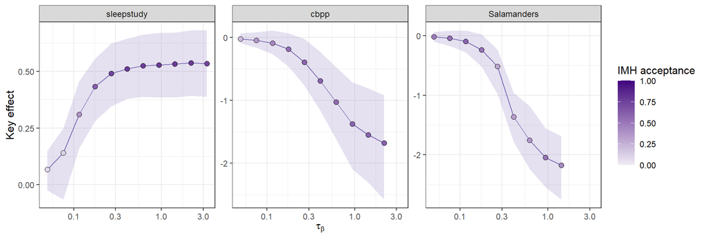

```r
slice <- do.call(rbind, lapply(names(SENSITIVITY), function(name) {
  x <- sensitivity[sensitivity$dataset == name & sensitivity$sd_family == "halfnormal", ]
  x[x$tau_sd == max(x$tau_sd[x$tau_sd <= 2.5]), ]
}))
slice$dataset <- factor(slice$dataset, levels = names(SENSITIVITY))
ggplot(slice, aes(tau_beta, key_q50)) +
  geom_ribbon(aes(ymin = key_q05, ymax = key_q95), fill = "#7b68b5", alpha = 0.2) +
  geom_line(colour = "#7b68b5") +
  geom_point(aes(fill = accept), shape = 21, size = 2.2) +
  scale_fill_gradient(low = "#efedf5", high = "#3f007d", limits = c(0, 1), name = "IMH acceptance") +
  scale_x_log10() +
  facet_wrap(~dataset, scales = "free_y") +
  labs(x = expression(tau[beta]), y = "Key effect") +
  theme_bw()
```

IMH acceptance over the grid (Table B11 reports 0.74 ± 0.07, 0.61 ± 0.05 and 0.48 ± 0.09 over the priors where NUTS converged), and the number of priors at which a built-in diagnostic fires (acceptance below 0.2 or the Pareto k of the network’s proposal weights above 0.7; the paper’s flags concentrate on the two tightest slope priors of `sleepstudy`):

```r
do.call(rbind, lapply(split(sensitivity, sensitivity$dataset), function(x) {
  data.frame(dataset = x$dataset[1], priors = nrow(x), `IMH acceptance` = med_mad(x$accept),
    `diagnostic fires` = sum(x$accept < 0.2 | x$pool_k > 0.7), `brm() warned` = sum(x$warned),
    check.names = FALSE)
}))[names(SENSITIVITY), ]
```

|  | dataset | priors | IMH acceptance | diagnostic fires | brm() warned |
| --- | --- | --- | --- | --- | --- |
| sleepstudy | sleepstudy | 132 | 0.74 ± 0.07 | 24 | 27 |
| cbpp | cbpp | 60 | 0.59 ± 0.04 | 4 | 1 |
| Salamanders | Salamanders | 54 | 0.48 ± 0.06 | 7 | 13 |

## 3.3 Bayes factors across priors (Fig. B16)

The same fits yield the marginal likelihood (`bridge_sampler()`, computed during the fit by importance sampling from a Student-t fitted to the posterior; no bridge sampling is run). On `sleepstudy`, ln BF of each slope prior against the Bambi-like reference (Normal, τβ = 2.16, half-Normal(2.5) SD prior). The paper finds that the data prefer τβ ≈ 0.4–0.6 over the reference (ln BF ≈ +0.9) and reject τβ = 0.05 (ln BF ≤ −6). Hollow markers have Pareto k > 0.7.

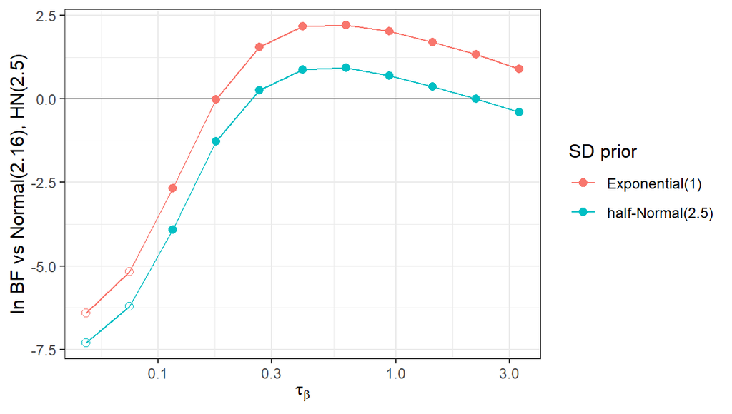

```r
sleep <- sensitivity[sensitivity$dataset == "sleepstudy", ]
reference <- sleep$logml[sleep$sd_family == "halfnormal" & sleep$tau_sd == 2.5 & abs(sleep$tau_beta - TAU_BETA[10]) < 1e-9]
bf <- sleep[(sleep$sd_family == "halfnormal" & sleep$tau_sd == 2.5) | (sleep$sd_family == "exponential" & sleep$tau_sd == 1), ]
bf$curve <- ifelse(bf$sd_family == "halfnormal", "half-Normal(2.5)", "Exponential(1)")
bf$log_bf <- bf$logml - reference
bf$reliable <- bf$evidence_k <= 0.7
ggplot(bf, aes(tau_beta, log_bf, colour = curve)) +
  geom_hline(yintercept = 0, colour = "grey50") +
  geom_line() +
  geom_point(aes(shape = reliable), size = 2) +
  scale_shape_manual(values = c(`TRUE` = 16, `FALSE` = 1), guide = "none") +
  scale_x_log10() +
  labs(x = expression(tau[beta]), y = "ln BF vs Normal(2.16), HN(2.5)", colour = "SD prior") +
  theme_bw()
```

```r
bf[order(bf$curve, bf$tau_beta), c("curve", "tau_beta", "log_bf", "evidence_k", "accept")]
```

|  | curve | tau_beta | log_bf | evidence_k | accept |
| --- | --- | --- | --- | --- | --- |
| 100 | Exponential(1) | 0.0500000 | -6.4065851 | 0.8266844 | 0.1222500 |
| 101 | Exponential(1) | 0.0759956 | -5.1670208 | 0.8187749 | 0.1475000 |
| 102 | Exponential(1) | 0.1155065 | -2.6832055 | 0.3747228 | 0.3970000 |
| 103 | Exponential(1) | 0.1755596 | -0.0215122 | 0.2693667 | 0.6577500 |
| 104 | Exponential(1) | 0.2668350 | 1.5572636 | 0.1834454 | 0.7797500 |
| 105 | Exponential(1) | 0.4055654 | 2.1615415 | 0.0430721 | 0.8010000 |
| 106 | Exponential(1) | 0.6164234 | 2.2102609 | 0.2064408 | 0.8017499 |
| 107 | Exponential(1) | 0.9369087 | 2.0241491 | 0.2118620 | 0.7997500 |
| 108 | Exponential(1) | 1.4240179 | 1.7031704 | 0.1557103 | 0.7955000 |
| 109 | Exponential(1) | 2.1643806 | 1.3328097 | 0.1624640 | 0.7690000 |
| 110 | Exponential(1) | 3.2896661 | 0.9034472 | 0.0707707 | 0.7235000 |
| 23 | half-Normal(2.5) | 0.0500000 | -7.3018632 | 0.8871724 | 0.0845000 |
| 24 | half-Normal(2.5) | 0.0759956 | -6.2030062 | 1.1176039 | 0.1092500 |
| 25 | half-Normal(2.5) | 0.1155065 | -3.9086484 | 0.3202272 | 0.3762500 |
| 26 | half-Normal(2.5) | 0.1755596 | -1.2814262 | 0.3026802 | 0.6270000 |
| 27 | half-Normal(2.5) | 0.2668350 | 0.2560430 | 0.1897519 | 0.7457500 |
| 28 | half-Normal(2.5) | 0.4055654 | 0.8767391 | 0.2070308 | 0.7732500 |
| 29 | half-Normal(2.5) | 0.6164234 | 0.9259920 | 0.1987291 | 0.7685000 |
| 30 | half-Normal(2.5) | 0.9369087 | 0.7013457 | 0.3145320 | 0.7775000 |
| 31 | half-Normal(2.5) | 1.4240179 | 0.3709464 | 0.2845107 | 0.7797500 |
| 32 | half-Normal(2.5) | 2.1643806 | 0.0000000 | 0.1128508 | 0.7732500 |
| 33 | half-Normal(2.5) | 3.2896661 | -0.3913763 | 0.2674056 | 0.7347500 |

# 4 Deployment safeguards (App. D.6)

**Support validation.** Data outside the training ranges are rejected with an explanation. `epil` has four observations per patient, the networks need at least five:

```r
data("epil", package = "MASS")
brm(y ~ trt + base + age + (1 | subject), data = epil, family = poisson())
```

```
#> Error:
#> ! The data lie outside the range metabeta's networks were trained on: 4 rows per group (supported: 5 to 150)
#> (d: population-level coefficients, q: group-level coefficients, m: groups, n_i: observations per group). Use brms::brm() for this model.
```

**Acceptance gate, MAP check and the Pareto k of the evidence.** The tightest slope prior of the `sleepstudy` grid, where the paper’s flags concentrate:

```r
spec <- SENSITIVITY$sleepstudy
tight <- brm(spec$formula, data = spec$data, seed = 1,
  prior = sensitivity_prior(spec, TAU_BETA[1], "halfnormal", 2.5))
str(tight$metabeta$safeguards)
```

```
#> List of 14
#>  $ refine_method      : chr "imhMarginal"
#>  $ accept_rate        : num 0.125
#>  $ accept_threshold   : num 0.1
#>  $ accept_flag        : logi FALSE
#>  $ suggested_n_samples: num 6000
#>  $ ess_min            : num 37.2
#>  $ ess_threshold      : int 150
#>  $ ess_flag           : logi TRUE
#>  $ random_walk_ran    : logi FALSE
#>  $ random_walk_accept : num NaN
#>  $ psis_k             : num 1.04
#>  $ map_z              : num 8.44
#>  $ map_z_threshold    : num 5
#>  $ map_z_flag         : logi TRUE
```

```r
bridge_sampler(tight)
```

```
#> Importance sampling estimate of the log marginal likelihood: -174.7559
#> Estimate obtained from 4000 draws of a Student-t fitted to the posterior (Pareto k of the weights: 1.04).
```

# 5 What is not reproduced here

| Paper result | Why not | Where |
| --- | --- | --- |
| NUTS, ADVI and Laplace rows of every table | baselines, not metabeta | `experiments/` (Python) |
| Agreement with NUTS: r, σ-ratio, rank-MAD, ΔLOO-NLL (Tables B4–B6, B11 left half, C1, D1–D12 left halves, Table 2) | needs the NUTS reference fits | `experiments/evaluation/` |
| Real-world test sets (Tables B4–B6, D10–D12) | built by a hierarchical bootstrap of 40 preprocessed datasets (Table F3) inside the Python research pipeline | `experiments/evaluation/real_posterior.py`, `condition_number.py` |
| Marginal likelihood against bridge sampling (Table B9) | the reference is bridge sampling on NUTS draws | `experiments/posthoc/evidence.py` |
| Warm-started NUTS (App. C.2, Table C5) | NUTS | `experiments/posthoc/warmstart_nuts.py` |
| Prior-awareness check and emulated fixed prior (App. B.8, B.9) | probe the raw network with overwritten prior inputs, below the brms interface | `experiments/evaluation/prior_families.py`, `fixed_prior.py` |
| GPU timings (Table B8, left) | `options(metabeta.device = "cuda")` runs on a GPU, but R adds its own overhead per fit |  |
| Survey and dataset tables (App. F.1, Table F3) | not metabeta results | `experiments/survey/` |

```r
reticulate::py_config()
```

[output not shown]